# Practica-02

Nombre : Jaime Gomez Marin

## Pregunta 1

a). Realice el análisis de variancia pruebe las hipótesis correspondientes. De las conclusiones y recomendaciones adecuadas para este caso.

```r
library(agricolae)
luminosidad <- read.table("luminosidad.txt", header = TRUE)
head(luminosidad)
```

[output not shown]

```r
str(luminosidad)
```

```
## 'data.frame':    27 obs. of  4 variables:
##  $ luminosidad: int  280 290 285 300 310 295 290 285 290 230 ...
##  $ tipo_vidrio: int  1 1 1 1 1 1 1 1 1 2 ...
##  $ temperatura: Factor w/ 3 levels "alta","baja",..: 2 2 2 3 3 3 1 1 1 2 ...
##  $ repeticion : int  1 2 3 1 2 3 1 2 3 1 ...
```

```r
luminosidad$tipo_vidrio <- factor(luminosidad$tipo_vidrio)
luminosidad$temperatura <- factor(luminosidad$temperatura)
#luminosidad$repeticion <- factor(luminosidad$repeticion)

str(luminosidad)
```

```
## 'data.frame':    27 obs. of  4 variables:
##  $ luminosidad: int  280 290 285 300 310 295 290 285 290 230 ...
##  $ tipo_vidrio: Factor w/ 3 levels "1","2","3": 1 1 1 1 1 1 1 1 1 2 ...
##  $ temperatura: Factor w/ 3 levels "alta","baja",..: 2 2 2 3 3 3 1 1 1 2 ...
##  $ repeticion : int  1 2 3 1 2 3 1 2 3 1 ...
```

```r
mod<-lm(luminosidad~tipo_vidrio+temperatura+tipo_vidrio*temperatura ,data=luminosidad)
anva<-anova(mod)
anva
```

[output not shown]

$H_0$ : $(\alpha * \beta )_ = 0$ , para i,j = 1,2,3

$H_1$ : al menos dos $(\alpha * \beta ) != 0$ , para i,j = 1,2,3

Se acepta $H_0$, no se ha encontrado suficiente evidencia estadistica para rechazar la $H_0$ de que ning'un efecto de la interaci'on entre el tipo de vidrio y la temperatura de operaci'on del foco influye sobre la luminicidad producida por un tubo de osciloscopio.

$H_0$ : $\alpha_i = 0$ , para i = 1,2,3

$H_1$ : al menos dos $\alpha_i != 0$ , para i = 1,2,3

Se rechaza la $H_0$, a un nivel de significacion del 0.1%, se ha encontrado suficientes evidencia estadistica para rechazar la $H_0$ de que el tipo de vidrio tenga un efecto significativo sobre la luminicidad producida por un tubo de osciloscopio.Por lo tanto, se puede aceptar de que existe diferencias significativas entre al menos dos lumnicidad producida por un tubo de osciloscopio entre dos tipos de vidrios.

$H_0$ : $\beta_j$ = 0 , para j = 1,2,3

$H_1$ : al menos dos $\beta_j != 0$ , para j = 1,2,3

b).- Realice el diagnóstico del modelo

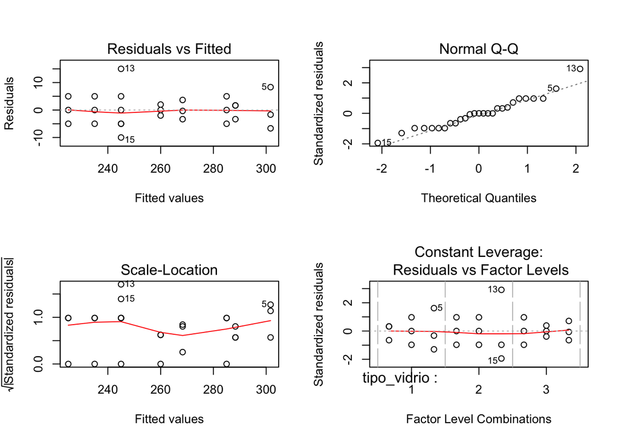

```r
par(mfrow=c(2,2))
plot(mod)
```

Prueba de Shapiro $H_0$: La distribucion de los errores es la distribucion normal $H_1$: La distribucion de los errores es diferente a la distribucion normal

```r
ri<-rstandard(mod)
shapiro.test(ri)
```

```
##
##  Shapiro-Wilk normality test
##
## data:  ri
## W = 0.95332, p-value = 0.2578
```

Se acepta la $H_0$, a un nivel de significancia de 10% (Se puede recomendar que se haga mas numero de repeticiones)

```r
library(car)
ncvTest(mod)
```

[output not shown]

### Cumple con el supuesto de homogeneidad de variancia

3. Realice el análisis de efecto simple asumiendo que se cumple con los supuestos

```r
anva<-anova(mod)
anva
```

```
## Analysis of Variance Table
##
## Response: luminosidad
##                         Df  Sum Sq Mean Sq  F value    Pr(>F)
## tipo_vidrio              2 14635.2  7317.6 183.9618 1.045e-12 ***
## temperatura              2  1635.2   817.6  20.5540 2.252e-05 ***
## tipo_vidrio:temperatura  4   270.4    67.6   1.6993     0.194
## Residuals               18   716.0    39.8
## ---
## Signif. codes:  0 '***' 0.001 '**' 0.01 '*' 0.05 '.' 0.1 ' ' 1
```

```r
summary(anva)
```

```
##        Df           Sum Sq           Mean Sq           F value
##  Min.   : 2.0   Min.   :  270.4   Min.   :  39.78   Min.   :  1.699
##  1st Qu.: 2.0   1st Qu.:  604.6   1st Qu.:  60.64   1st Qu.: 11.127
##  Median : 3.0   Median : 1175.6   Median : 442.59   Median : 20.554
##  Mean   : 6.5   Mean   : 4314.2   Mean   :2060.64   Mean   : 68.738
##  3rd Qu.: 7.5   3rd Qu.: 4885.2   3rd Qu.:2442.59   3rd Qu.:102.258
##  Max.   :18.0   Max.   :14635.2   Max.   :7317.59   Max.   :183.962
##                                                     NA's   :1
##      Pr(>F)
##  Min.   :0.0000000
##  1st Qu.:0.0000113
##  Median :0.0000225
##  Mean   :0.0646747
##  3rd Qu.:0.0970121
##  Max.   :0.1940017
##  NA's   :1
```

```r
CMe <- anva$"Mean Sq"
CME <- CMe[5]
CME
```

```
## [1] NA
```

```r
SCe <- anva$"Sum Sq"
SCE <- SCe[4]
SCE
```

```
## [1] 716
```

```r
head(luminosidad)
```

```
##   luminosidad tipo_vidrio temperatura repeticion
## 1         280           1        baja          1
## 2         290           1        baja          2
## 3         285           1        baja          3
## 4         300           1       media          1
## 5         310           1       media          2
## 6         295           1       media          3
```

#La data se divide por tipos de vidrio (tipo_vidrio=1, tipo_vidrio=2 y tipo_vidrio=3)

```r
lumninosidad_x_tipo_vidrio_1 <- luminosidad[luminosidad$tipo_vidrio=="1",]
lumninosidad_x_tipo_vidrio_1
```

```
##   luminosidad tipo_vidrio temperatura repeticion
## 1         280           1        baja          1
## 2         290           1        baja          2
## 3         285           1        baja          3
## 4         300           1       media          1
## 5         310           1       media          2
## 6         295           1       media          3
## 7         290           1        alta          1
## 8         285           1        alta          2
## 9         290           1        alta          3
```

```r
lumninosidad_x_tipo_vidrio_2 <- luminosidad[luminosidad$tipo_vidrio=="2",]
lumninosidad_x_tipo_vidrio_2
```

```
##    luminosidad tipo_vidrio temperatura repeticion
## 10         230           2        baja          1
## 11         235           2        baja          2
## 12         240           2        baja          3
## 13         260           2       media          1
## 14         240           2       media          2
## 15         235           2       media          3
## 16         220           2        alta          1
## 17         225           2        alta          2
## 18         230           2        alta          3
```

```r
lumninosidad_x_tipo_vidrio_3 <- luminosidad[luminosidad$tipo_vidrio=="3",]
lumninosidad_x_tipo_vidrio_3
```

```
##    luminosidad tipo_vidrio temperatura repeticion
## 19         260           3        baja          1
## 20         258           3        baja          2
## 21         262           3        baja          3
## 22         265           3       media          1
## 23         272           3       media          2
## 24         268           3       media          3
## 25         245           3        alta          1
## 26         250           3        alta          2
## 27         240           3        alta          3
```

```r
lumninosidad_x_temp_baja <- luminosidad[luminosidad$temperatura=="baja",]
lumninosidad_x_temp_baja
```

```
##    luminosidad tipo_vidrio temperatura repeticion
## 1          280           1        baja          1
## 2          290           1        baja          2
## 3          285           1        baja          3
## 10         230           2        baja          1
## 11         235           2        baja          2
## 12         240           2        baja          3
## 19         260           3        baja          1
## 20         258           3        baja          2
## 21         262           3        baja          3
```

```r
lumninosidad_x_temp_media <- luminosidad[luminosidad$temperatura=="media",]
lumninosidad_x_temp_media
```

```
##    luminosidad tipo_vidrio temperatura repeticion
## 4          300           1       media          1
## 5          310           1       media          2
## 6          295           1       media          3
## 13         260           2       media          1
## 14         240           2       media          2
## 15         235           2       media          3
## 22         265           3       media          1
## 23         272           3       media          2
## 24         268           3       media          3
```

```r
lumninosidad_x_temp_alta <- luminosidad[luminosidad$temperatura=="alta",]
lumninosidad_x_temp_alta
```

```
##    luminosidad tipo_vidrio temperatura repeticion
## 7          290           1        alta          1
## 8          285           1        alta          2
## 9          290           1        alta          3
## 16         220           2        alta          1
## 17         225           2        alta          2
## 18         230           2        alta          3
## 25         245           3        alta          1
## 26         250           3        alta          2
## 27         240           3        alta          3
```

```r
mod_tipo_vidrio_1 <- lm(luminosidad ~ as.factor(temperatura),lumninosidad_x_tipo_vidrio_1)
mod_tipo_vidrio_2 <- lm(luminosidad ~ as.factor(temperatura),lumninosidad_x_tipo_vidrio_2)
mod_tipo_vidrio_3 <- lm(luminosidad ~ as.factor(temperatura),lumninosidad_x_tipo_vidrio_3)

anva_tipo_vidrio_1 <- anova(mod_tipo_vidrio_1)
anva_tipo_vidrio_2 <- anova(mod_tipo_vidrio_2)
anva_tipo_vidrio_3 <- anova(mod_tipo_vidrio_3)

SCM_TV1 <- anva_tipo_vidrio_1$Sum[1]
SCM_TV2 <- anva_tipo_vidrio_2$Sum[1]
SCM_TV3 <- anva_tipo_vidrio_3$Sum[1]

CMM_TV1 <- anva_tipo_vidrio_1$Mean[1]
CMM_TV2 <- anva_tipo_vidrio_2$Mean[1]
CMM_TV3 <- anva_tipo_vidrio_3$Mean[1]
```

```r
mod_temp_baja  <- lm(luminosidad ~ as.factor(tipo_vidrio),lumninosidad_x_temp_baja)
mod_temp_media <- lm(luminosidad ~ as.factor(tipo_vidrio),lumninosidad_x_temp_media)
mod_temp_alta  <- lm(luminosidad ~ as.factor(tipo_vidrio),lumninosidad_x_temp_alta)

anva_temp_baja  <- anova(mod_temp_baja)
anva_temp_media <- anova(mod_temp_media)
anva_temp_alta  <- anova(mod_temp_alta)

SCT_TB <- anva_temp_baja$Sum[1]
SCT_TM <- anva_temp_media$Sum[1]
SCT_TA <- anva_temp_alta$Sum[1]

CMT_TB <- anva_temp_baja$Mean[1]
CMT_TM <- anva_temp_media$Mean[1]
CMT_TA <- anva_temp_alta$Mean[1]
```

Suma de cuadrados

```r
SC  <- round(c(SCM_TV1,SCM_TV2,SCM_TV3,SCT_TB,SCT_TM,SCT_TA,SCE),6)
GLE <- 18
CME <- SCE/GLE
```

Cuadrado medio

```r
CM  <- round(c(CMM_TV1,CMM_TV2,CMM_TV3,CMT_TB,CMT_TM,CMT_TA,CME),6)
# Grados de libertad
GL  <- c(rep(2,6), GLE)
Fc1 <- round(CM[1:6]/CM[7],6)
Fc  <- c(Fc1,"")
```

```r
pvalue1 <-  round(1-pf(Fc1,2,GLE),6)
pvalue  <-  c(pvalue1,"")
```

```r
Fuente <- c("A es b1","A es b2","A es b3","B es b1","B es b2","B es b3","residuales")
data.frame(Fuente, GL, SC, CM, Fc, pvalue)
```

```
##       Fuente GL        SC         CM        Fc   pvalue
## 1    A es b1  2  466.6667  233.33333  5.865922 0.010926
## 2    A es b2  2  600.0000  300.00000  7.541899 0.004177
## 3    A es b3  2  838.8889  419.44444 10.544693 0.000931
## 4    B es b1  2 3750.0000 1875.00000 47.136871        0
## 5    B es b2  2 4866.6667 2433.33333 61.173184        0
## 6    B es b3  2 6288.8889 3144.44444 79.050279        0
## 7 residuales 18  716.0000   39.77778
```

4. Para una temperatura alta realice la prueba de Tukey para comparar las medias de luminosidad producidos entre los tipos de vidrios. De sus conclusiones y recomendaciones en términos de las variables en estudios.

```r
aov_temp_alta<-aov(mod_temp_alta)
tHSD <- TukeyHSD(aov_temp_alta)
print(tHSD)
```

```
##   Tukey multiple comparisons of means
##     95% family-wise confidence level
##
## Fit: aov(formula = mod_temp_alta)
##
## $`as.factor(tipo_vidrio)`
##          diff        lwr       upr     p adj
## 2-1 -63.33333 -74.380384 -52.28628 0.0000049
## 3-1 -43.33333 -54.380384 -32.28628 0.0000493
## 3-2  20.00000   8.952949  31.04705 0.0034732
```

5. Para una temperatura alta realice la prueba de Duncan para comparar las medias de luminosidad producidos entre los tipos de vidrios. De sus conclusiones y recomendaciones en términos de las variables en estudios. Compare con lo obtenido en d)

```r
#aov_temp_alta <- aov(mod_temp_alta)
summary(aov_temp_alta)
```

```
##                        Df Sum Sq Mean Sq F value   Pr(>F)
## as.factor(tipo_vidrio)  2   6289  3144.4   161.7 6.04e-06 ***
## Residuals               6    117    19.4
## ---
## Signif. codes:  0 '***' 0.001 '**' 0.01 '*' 0.05 '.' 0.1 ' ' 1
```

```r
comp <- duncan.test(aov_temp_alta,"as.factor(tipo_vidrio)")
comp
```

```
## $statistics
##    MSerror Df     Mean       CV
##   19.44444  6 252.7778 1.744451
##
## $parameters
##     test                 name.t ntr alpha
##   Duncan as.factor(tipo_vidrio)   3  0.05
##
## $duncan
##      Table CriticalRange
## 2 3.460456      8.809889
## 3 3.586498      9.130776
##
## $means
##   luminosidad      std r Min Max   Q25 Q50   Q75
## 1    288.3333 2.886751 3 285 290 287.5 290 290.0
## 2    225.0000 5.000000 3 220 230 222.5 225 227.5
## 3    245.0000 5.000000 3 240 250 242.5 245 247.5
##
## $comparison
## NULL
##
## $groups
##   luminosidad groups
## 1    288.3333      a
## 3    245.0000      b
## 2    225.0000      c
##
## attr(,"class")
## [1] "group"
```

6. Para tipo de vidrio tres, se desea comparar la media de luminosidad de b2 versus (b1 y b3) ¿Qué supuestos se deben cumplir para poder realizar esta comparación? Asumiendo que se cumple estos supuestos, utilice la prueba de T para realizar esta comparación.

$\mu_{baja}$ = media de luminosidad para una temperatura baja cuando se usa el tipo de vidrio 3. $\mu_{media}$ = media de luminosidad para una temperatura media cuando se usa el tipo de vidrio 3. $\mu_{alta}$ = media de luminosidad para una temperatura alta cuando se usa el tipo de vidrio 3.

## Hipotesis :

$H_O$: 2$\mu_{media}$ = $\mu_{baja}$ + $\mu_{alta}$ $H_1$: 2$\mu_{media}$ != $\mu_{baja}$ + $\mu_{alta}$

## Matriz de Ortogonales :

## Coeficientes | $T_{baja}$ | $T_{media}$ | $T_{alta}$

$C_{11}$ | 1 | -2 | 1

## Constrastes Ortogonales :

$Q_{1}$ = $Y_{baja}$ - 2$Y_{media}$ + $Y_{alta}$

```r
aov_tipo_vidrio_3 <- aov(mod_tipo_vidrio_3)
summary(aov_tipo_vidrio_3)
```

```
##                        Df Sum Sq Mean Sq F value   Pr(>F)
## as.factor(temperatura)  2  838.9   419.4   30.44 0.000722 ***
## Residuals               6   82.7    13.8
## ---
## Signif. codes:  0 '***' 0.001 '**' 0.01 '*' 0.05 '.' 0.1 ' ' 1
```

```r
#summary(mod_tipo_vidrio_3)
```

```r
yp<-sort(tapply(lumninosidad_x_tipo_vidrio_3$luminosidad,lumninosidad_x_tipo_vidrio_3$temperatura,mean))
yp
```

```
##     alta     baja    media
## 245.0000 260.0000 268.3333
```

```r
c1<-c(1,1,-2)
tc<-(t(c1)%*%yp)/sqrt((13.8/2)*sum(c1^2))
tc
```

```
##           [,1]
## [1,] -4.921553
```

```r
pvalue<-2*(1-pt(tc,6))
pvalue
```

```
##          [,1]
## [1,] 1.997347
```

7. Utilice la prueba de Scheffe para probar la comparación dado en f). De sus conclusiones y recomendaciones en términos de las variables en estudios. Compare con lo obtenido en f)

```r
# Se calcula el valor estandard
absl <- t(c1)%*%yp
absl
```

```
##           [,1]
## [1,] -31.66667
```

```r
sdl <- sqrt(( 13.8/2)*sum(c1^2))
sdl
```

```
## [1] 6.434283
```

```r
vcs <- sdl*sqrt(3*qf(0.95,2,6))
vcs
```

```
## [1] 25.27433
```